# R Assignment 3: Downloading Data & Reproducing Figure

We will start by creating a simple bar chart of the age distribution in our data.

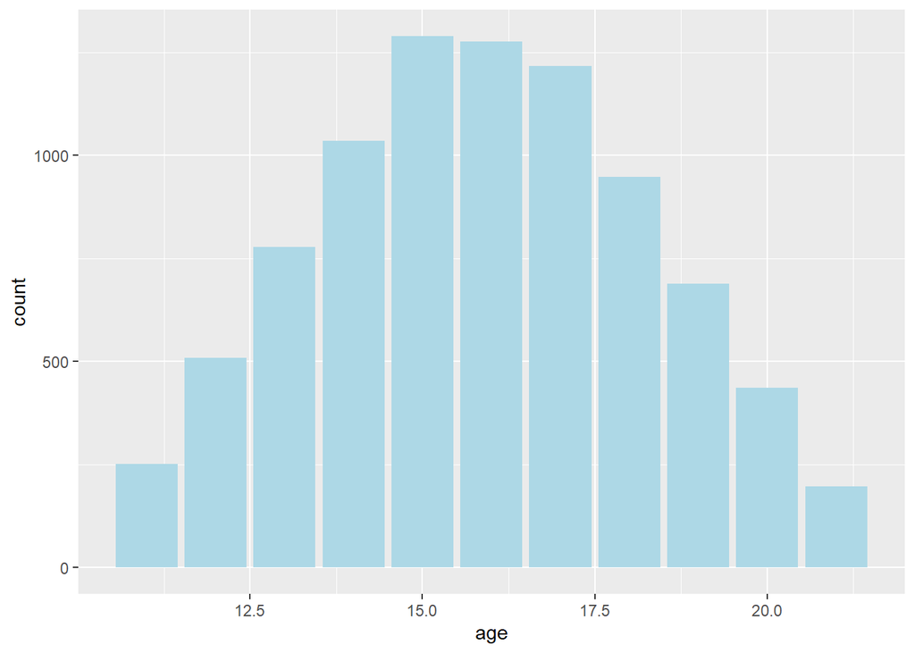

```r
nys_fwtrim_dic %>%
  ggplot(aes(x = age)) +
  geom_bar(fill = "lightblue")
```

- *Note:* We added the “geom” layer to the plot by using the `+` symbol and then telling `ggplot()` what I wanted to add (in this case a “geom_bar” ). Once you start a `ggplot()`, this is generally how you add layers and/or features to the chart - you simply follow the logic of starting with a basic plot and then sequentially adding (`+`) layers to it.
- *Note:* In this plot, we told R to use the `geom_bar()` geom to represent the age data as a bar chart. Also, note that we told geom_bar() to make the bars light blue with `fill = "lightblue"`. There are numerous built in colors available in R (see [here](http://sape.inf.usi.ch/quick-reference/ggplot2/colour)) and you can enter [hexadecimal color values](https://en.wikipedia.org/wiki/Web_colors) by placing a “#” before the appropriate value (e.g., `fill = #add8e6`). In general, we recommend using colorblind-friendly palettes whenever possible.
- *Note:* the `fill` controls the color of the fill for a particular geom. If you want to change the color of the lines around the individual bars, you would add a `color =` command to the geom. Here I’ll add `color = "black"` in order to make the bars stand out a little more.

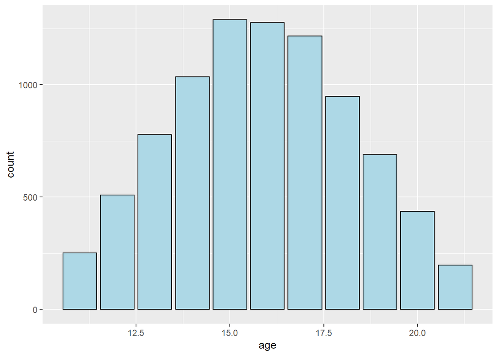

```r
nys_fwtrim_dic %>%
  ggplot(aes(x = age)) +
  geom_bar(fill = "lightblue", color = "black")
```

- We could spend a lot of time going through these kinds of basic `ggplot` skills. For now, we want just want you to understand that any ggplot is essentially built as a bunch of layers with specific aesthetics mapped to different variables and visual features as well as different geoms used to represent the data in specific ways. Let’s move on the plots that we are actually trying to re-create from Warr’s (1993) Figure 1.

#### 2. Wrangle data and plot part of Figure 1

- Sometimes, as above, we can just take the raw data and plot it. But this is actually pretty rare. Usually we need to wrangle and recode data to get it in the form we want to plot. In this case, you already started this process earlier when you created dichotomous variables for the peer delinquency variables (e.g., “mardic” and “alcdic”). Now, we need to use these dichotomous variables to create a summary of the data that reflects the “percentage of respondents with no delinquent friends” for each age group. To do that we will go back to “dplyr” and use the `group_by()` and `summarize()` functions. Essentially, we want to create a data frame that looks like the top row in from the `flat_table()` command that we used above to summarize the data.

```r
nys_fwmarsum = nys_fwtrim_dic %>%
  drop_na(marijuana) %>%
  group_by(age) %>%
  summarize(mean_mar = mean(mardic),
            perc_mar = 100 * mean_mar)

nys_fwalcsum = nys_fwtrim_dic %>%
  drop_na(alcohol) %>%
  group_by(age) %>%
  summarize(mean_alc = mean(alcdic),
            perc_alc = 100 * mean_alc)

nys_fwmarsum
```

```
## # A tibble: 11 × 3
##      age mean_mar perc_mar
##    <dbl>    <dbl>    <dbl>
##  1    11    0.949     94.9
##  2    12    0.873     87.3
##  3    13    0.760     76.0
##  4    14    0.637     63.7
##  5    15    0.508     50.8
##  6    16    0.397     39.7
##  7    17    0.329     32.9
##  8    18    0.249     24.9
##  9    19    0.266     26.6
## 10    20    0.239     23.9
## 11    21    0.186     18.6
```

```r
nys_fwalcsum
```

```
## # A tibble: 11 × 3
##      age mean_alc perc_alc
##    <dbl>    <dbl>    <dbl>
##  1    11   0.869     86.9
##  2    12   0.786     78.6
##  3    13   0.579     57.9
##  4    14   0.400     40.0
##  5    15   0.243     24.3
##  6    16   0.180     18.0
##  7    17   0.121     12.1
##  8    18   0.0820     8.20
##  9    19   0.0702     7.02
## 10    20   0.0688     6.88
## 11    21   0.0859     8.59
```

- In the above code, we created two separate summary data sets for each of the first two peer delinquency variables:
  - First, we told R to drop the missing values for each peer delinquency variable with the `drop_na()` function.
  - Second, we told R to group the data set by the variable “age.” This basically tells R to perform whatever functions come next within the values of the grouping variable - in this case age (e.g., within age==11; then within age==12; etc.).
  - Third, we used the `summarize` function to create a new summary data set with the variables calculated as instructed in the parentheses.
    - The first variable we created using the `mean` function provides the proportion of respondents in each age group who reported having no delinquent friends for the specific type of delinquency. In this case, the `mean` function returns a proportion only because we had created the “mardic” and “alcdic” variables as “dummy variables” earlier. When you calculate the mean of a dummy variable, the mean represents the proportion of cases that have the category coded as `1`.
    - Then, we simply multiplied that proportion by `100` to get a percentage (“perc_mar” and “perc_alc”) rather than a proportion.

#### 3. Plot the Data

- Now that we have these summary data, plotting them is relatively easy. We just need to tell ggplot what data to use and the specific geom we want to represent the data as. There are some other details, but I think we can get something that looks like Warr’s (1993) Figure 1 relatively quickly.

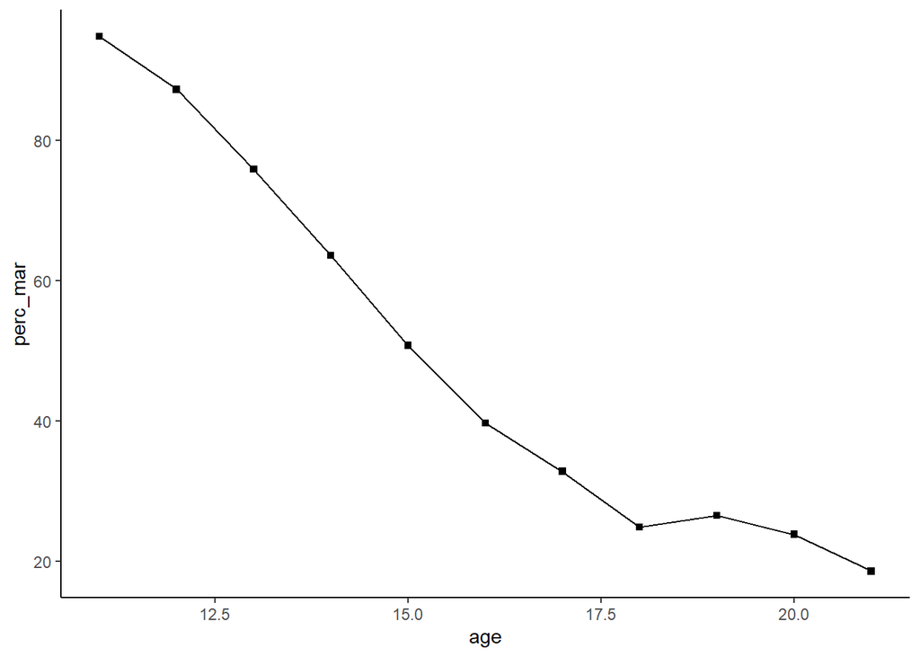

```r
theme_set(theme_classic())

marplot <- nys_fwmarsum %>%
  ggplot(aes(x = age, y = perc_mar)) +
  geom_line() +
  geom_point(shape = "square")

alcplot <- nys_fwalcsum %>%
  ggplot(aes(x = age, y = perc_alc)) +
  geom_line() +
  geom_point(shape = "square")

marplot
```

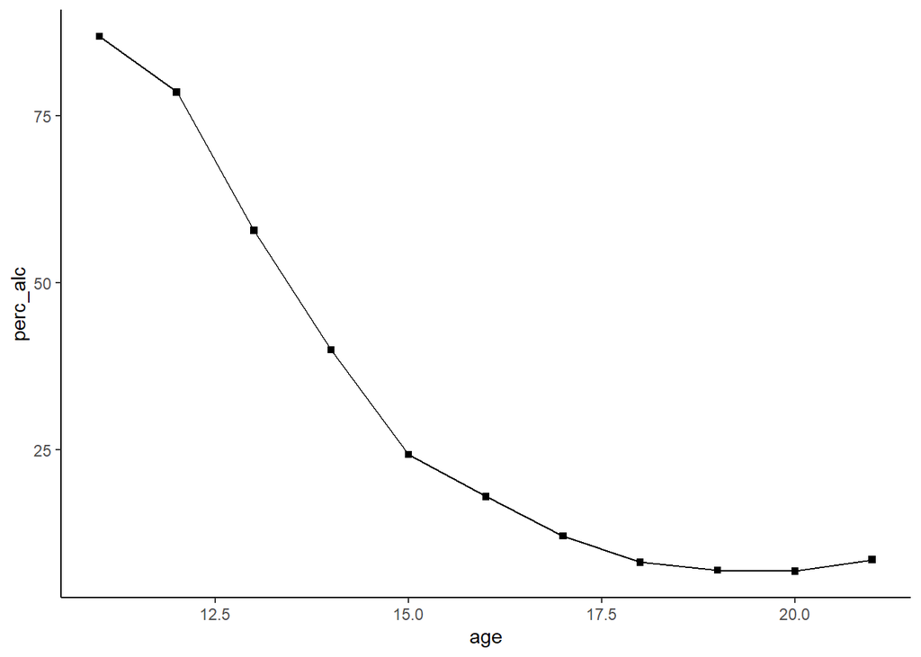

```r
alcplot
```

- There are a few of things to note in the above code:
  - First, notice that we constructed the plots with two geoms (geom_point and geom_line). This is ggplot2’s layering at work. In order to create the line plot with the points, we needed to first draw the line, then add the points (we could have drawn the points and then the lines, but then the line would technically be in front of the points).
  - Second, notice how we specified the specific shape we wanted inside the `geom_point()` command with `shape = "square"`. We could have also specified the number code for a solid square with `shape = 15` to get the same thing. There are lots of different built-in shapes you can use for points (see [here](https://ggplot2.tidyverse.org/articles/ggplot2-specs.html#point-1)).
  - Third, notice that above the code for the two plots, we included the line `theme_set(theme_classic())`. ggplot2 has multiple [built-in themes](https://ggplot2.tidyverse.org/reference/ggtheme.html) and `theme_classic()` is the most similar to the look or aesthetics used in Warr’s (1993) Figure 1 plots. Of course, these themes are all customizable, and there are multiple packages you can download with additional themes (e.g., “[ggthemes](https://yutannihilation.github.io/allYourFigureAreBelongToUs/ggthemes/)”).

#### 4. Customize plot details

- In the above plots, the actual data displayed appears to match up with that of Warr (1993). However, the details of the plot (e.g. axis labels, scales, etc.) are not exactly how we want them. The good news is that virtually everything within ggplot2 is customizable. So, we should be able to make these changes relatively easily.

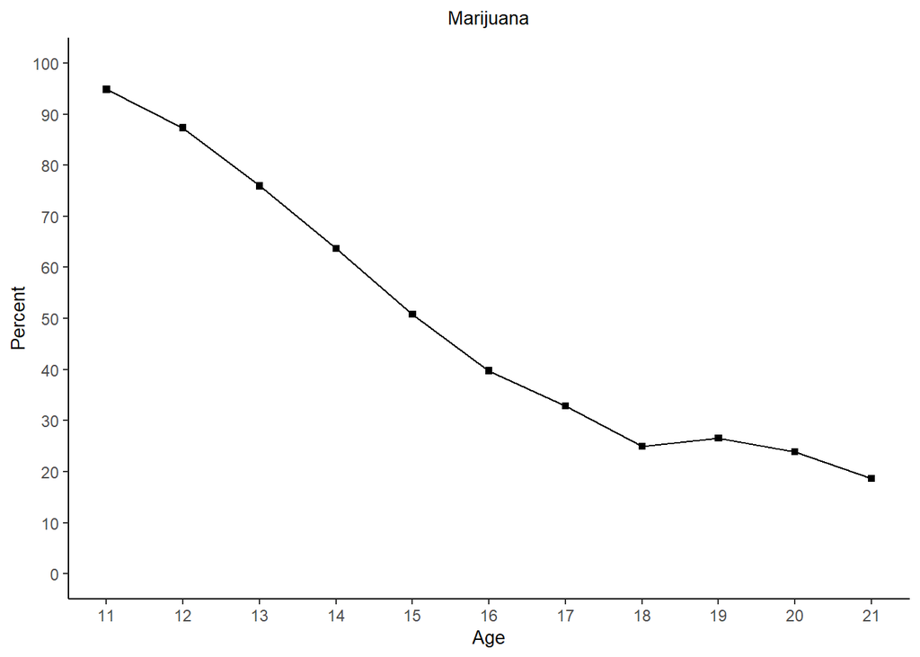

```r
marplot <- nys_fwmarsum %>%
  ggplot(aes(x = age, y = perc_mar)) +
  geom_line() +
  geom_point(shape = "square") +
  scale_x_continuous(limits = c(11, 21), breaks = 11:21) +
  scale_y_continuous(limits = c(0, 100), breaks = seq(0, 100, 10)) +
  labs (title = "Marijuana", x = "Age", y = "Percent") +
  theme(plot.title = element_text(hjust = 0.5, size = 10),
        axis.title = element_text(size = 10))

alcplot <- nys_fwalcsum %>%
  ggplot(aes(x = age, y = perc_alc)) +
  geom_line() +
  geom_point(shape = "square") +
  scale_x_continuous(limits = c(11, 21), breaks = 11:21) +
  scale_y_continuous(limits = c(0, 100), breaks = seq(0, 100, 10)) +
  labs (title = "Alcohol", x = "Age", y = "Percent") +
  theme(plot.title = element_text(hjust = 0.5, size = 10),
        axis.title = element_text(size = 10))

marplot
```

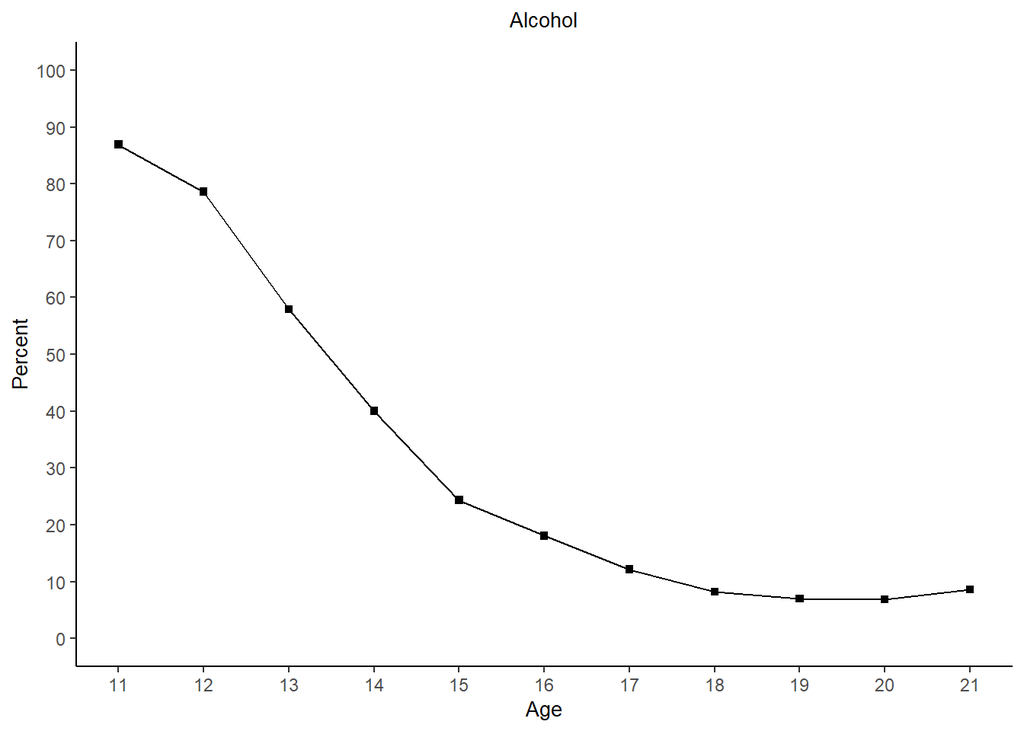

```r
alcplot
```

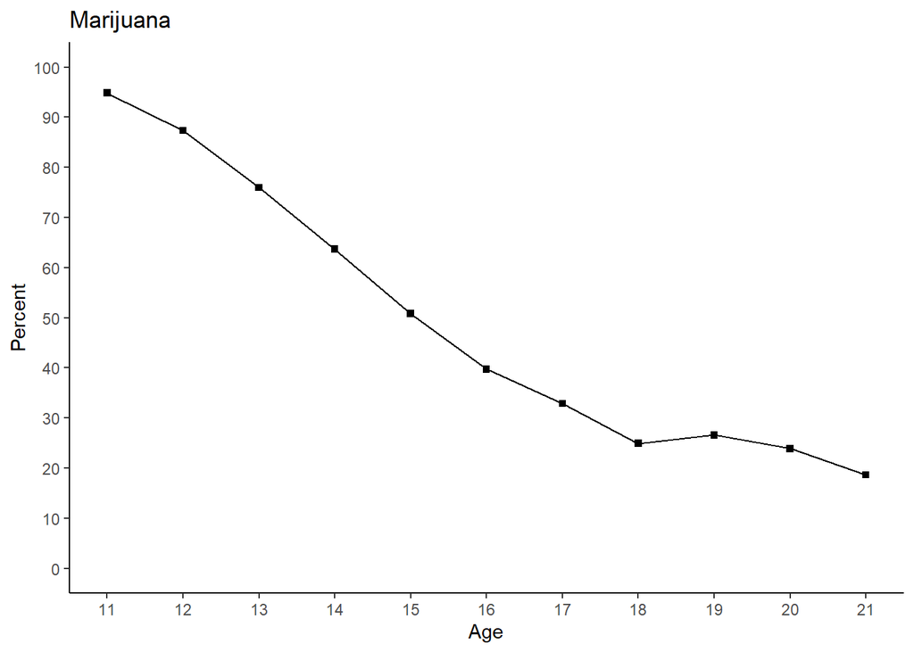

```r
nys_fwmarsum %>%
  ggplot(aes(x = age, y = perc_mar)) +
  geom_line() +
  geom_point(shape = "square") +
  scale_x_continuous(limits = c(11, 21), breaks = 11:21) +
  scale_y_continuous(limits = c(0, 100), breaks = seq(0, 100, 10)) +
  labs (title = "Marijuana", x = "Age", y = "Percent")
```

- As you can see, the title of the plot is now left-justified and the font is larger. We simply modified this in the previous plots by specifying a particular font size in the `theme()` command. The `hjust = 0.5` simply tells R to place the title of the plot in the center of ggplot’s coordinate system (find out more [here](https://ggplot2.tidyverse.org/articles/ggplot2-specs.html#text-1)). The `size = 10` simply tells ggplot2 to make the plot title and axis titles size 10 point font. There are almost endless ways to modify a ggplot2 theme (see [here](https://ggplot2.tidyverse.org/reference/theme.html) for details).

#### 5. Combine separate plots into one.

- The last thing we are going to do is show you how to combine separate plots into one, using the “[patchwork](https://patchwork.data-imaginist.com/)” package. There are lots of ways to produce multiple plots on the same overall canvas. The “patchwork” package seems, to us, to be the easiest way to combine plots.

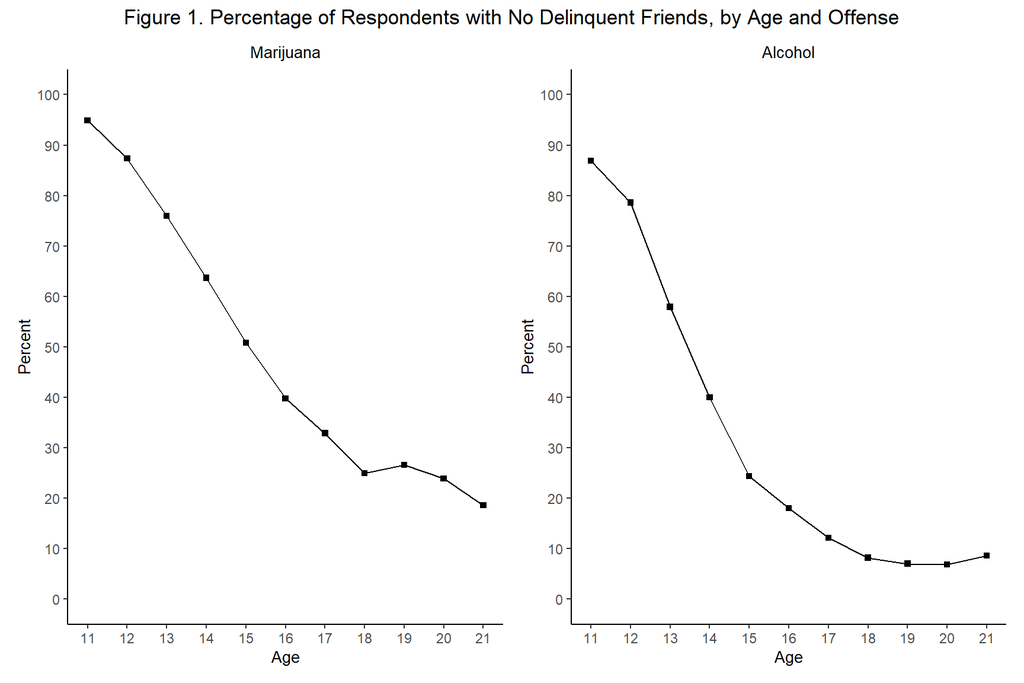

```r
library(patchwork)
fig1_maralc = (marplot | alcplot) +
  plot_annotation(
    title = "Figure 1. Percentage of Respondents with No Delinquent Friends, by Age and Offense",
    theme = theme(plot.title = element_text(hjust = 0.5)))
fig1_maralc
```

- *Note:* Look at the options for the R chunk (the text following the `{r`) - here we included knitted dimensions for the figure by writing `[r, fig.width = 9, fig.height = 6]`. This simply tells RMarkdown to produce a figure of those dimensions (essentially the size of regular letter-sized paper with one inch margins) - this will be particularly useful when knitting the final document.
- *Note:* In the above plot, we could have placed the two plots on top of each other instead by separating them with a `/` rather than a `|`, like so:

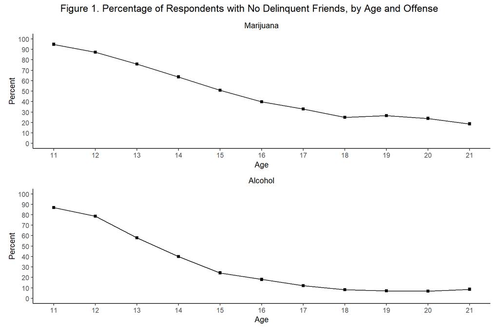

```r
fig1_maralc_vert <- (marplot / alcplot) +
  plot_annotation(
    title = "Figure 1. Percentage of Respondents with No Delinquent Friends, by Age and Offense",
    theme = theme(plot.title = element_text(hjust = 0.5)))
fig1_maralc_vert
```

- *Note:* If I had four separate plots and I wanted to arrange them all in a grid, I would just include the plots I wanted next to each other in parentheses like so:

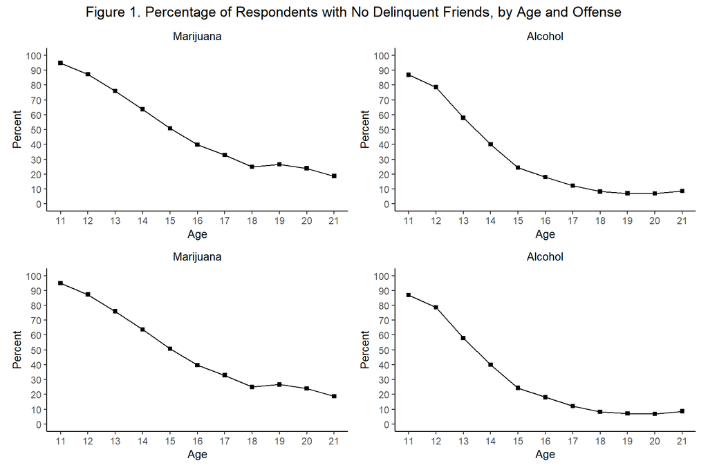

```r
fig1_maralc_grid <- (marplot | alcplot) / (marplot | alcplot) +
  plot_annotation(
    title = "Figure 1. Percentage of Respondents with No Delinquent Friends, by Age and Offense",
    theme = theme(plot.title = element_text(hjust = 0.5)))
fig1_maralc_grid
```

- In the above plot I just plotted the same marijuana and alcohol plots on the bottom. But, if you had two different plots, say one of peer cheating and peer vandalism, you could just replace the second set of objects with those and it would produce the top part of Warr’s (1993) Figure 1 displayed on pg. 22.

#### 6. “Draw the Owl”

You should now have everything that you need to recreate the first part of Figure 1 from Warr (1993) on pg. 22. If you have followed along up to this point, you should have the pooled data with dummy coded peer-deliquency variables needed to create summary data frames as done in Assignment section 3.6 above. You should also have the first two plots for Marijuana and Alcohol.

Remember:

1. Keep the file clean and easy to follow by using RMD level headings (e.g., denoted with ## or ###) separating R code chunks, organized by assignment parts or questions.
2. Write plain text after headings and before or after code chunks to explain what you are doing. This is not just for my sake - such text will serve as useful reminders to *you* when working on later assignments!
3. Upon completing the assignment, “knit” your final RMD file again and save the final knitted **html** document to your “Assignments” folder in your LastName_P680_work folder as: **LastName_P680_Assign3_YEAR_MO_DY**.
4. Inside the “LastName_P680_commit” folder in our shared folder, create another folder named: **Assignment 3**.
5. To submit your assignment for grading, save copies of both your (1) final knitted “Assign3” html file and (2) your “Assign3_RMD” file into the “LastName_P680_commit / Assignment 3” folder.
- Remember, be sure to save *copies* of both files - do not just drag the files over from your “work” folder, or you may lose those original copies from your “work” folder.

Finally, just to give you a sense that you are on the right track, your final plot should look something like this:

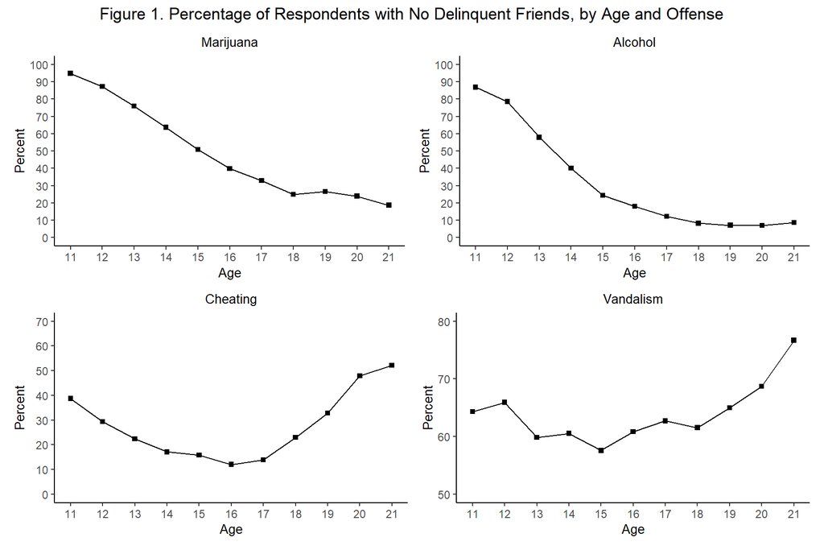